# Fifa Dataset Preprocessing

### The data is extracted from sofifa.com which was found on kaggle.com

#### https://www.kaggle.com/datasets/yagunnersya/fifa-21-messy-raw-dataset-for-cleaning-exploring

## The given Dataset had the following conditions for Preprocessing

##### 1.Convert the height and weight columns to numerical forms

##### 2.Remove the unnecessary newline characters from all columns that have them.

##### 3.'Value', 'Wage' and "Release Clause' are string columns. Convert them to numbers. For eg, "M" in value column is Million, so multiply the row values by 1,000,000, etc.

##### 4.Some columns have 'star' characters. Strip those columns of these stars and make the columns numerical

##### 5.Which players are highly valuable but still underpaid (on low wages)? (hint: scatter plot between wage and value)

#### Though the above conditions were met , there were still dirty and null values which had to be dealt with

### The following workbook contains the Preprocessing of the Data

```python
import numpy as np, pandas as pd
```

## 1. Loading the Dataset

```python
df=pd.read_csv(r'C:\Users\Dell\Desktop\ShaQ\Data Analytics\Kaggle\fifa21 raw data v2.1.csv')
```

## 2. Dataset Shape and Info

```python
print(df.shape,"\n \n")
print(df.info(),"\n \n")
```

```
(18979, 77)


<class 'pandas.core.frame.DataFrame'>
RangeIndex: 18979 entries, 0 to 18978
Data columns (total 77 columns):
 #   Column            Non-Null Count  Dtype
---  ------            --------------  -----
 0   ID                18979 non-null  int64
 1   Name              18979 non-null  object
 2   LongName          18979 non-null  object
 3   photoUrl          18979 non-null  object
 4   playerUrl         18979 non-null  object
 5   Nationality       18979 non-null  object
 6   Age               18979 non-null  int64
```

[output cut: 73 more lines]

```python
df.head()
```

|  | ID | Name | LongName | photoUrl | playerUrl | Nationality | Age | ↓OVA | POT | Club | Contract | Positions | Height | Weight | Preferred Foot | BOV | Best Position | Joined | Loan Date End | Value | Wage | Release Clause | Attacking | Crossing | Finishing | Heading Accuracy | Short Passing | Volleys | Skill | … |
| --- | --- | --- | --- | --- | --- | --- | --- | --- | --- | --- | --- | --- | --- | --- | --- | --- | --- | --- | --- | --- | --- | --- | --- | --- | --- | --- | --- | --- | --- | --- |
| 0 | 158023 | L. Messi | Lionel Messi | https://cdn.sofifa.com/players/158/023/21_60.png | http://sofifa.com/player/158023/lionel-messi/2... | Argentina | 33 | 93 | 93 | \n\n\n\nFC Barcelona | 2004 ~ 2021 | RW, ST, CF | 170cm | 72kg | Left | 93 | RW | Jul 1, 2004 | NaN | €103.5M | €560K | €138.4M | 429 | 85 | 95 | 70 | 91 | 88 | 470 | … |
| 1 | 20801 | Cristiano Ronaldo | C. Ronaldo dos Santos Aveiro | https://cdn.sofifa.com/players/020/801/21_60.png | http://sofifa.com/player/20801/c-ronaldo-dos-s... | Portugal | 35 | 92 | 92 | \n\n\n\nJuventus | 2018 ~ 2022 | ST, LW | 187cm | 83kg | Right | 92 | ST | Jul 10, 2018 | NaN | €63M | €220K | €75.9M | 437 | 84 | 95 | 90 | 82 | 86 | 414 | … |
| 2 | 200389 | J. Oblak | Jan Oblak | https://cdn.sofifa.com/players/200/389/21_60.png | http://sofifa.com/player/200389/jan-oblak/210006/ | Slovenia | 27 | 91 | 93 | \n\n\n\nAtlético Madrid | 2014 ~ 2023 | GK | 188cm | 87kg | Right | 91 | GK | Jul 16, 2014 | NaN | €120M | €125K | €159.4M | 95 | 13 | 11 | 15 | 43 | 13 | 109 | … |
| 3 | 192985 | K. De Bruyne | Kevin De Bruyne | https://cdn.sofifa.com/players/192/985/21_60.png | http://sofifa.com/player/192985/kevin-de-bruyn... | Belgium | 29 | 91 | 91 | \n\n\n\nManchester City | 2015 ~ 2023 | CAM, CM | 181cm | 70kg | Right | 91 | CAM | Aug 30, 2015 | NaN | €129M | €370K | €161M | 407 | 94 | 82 | 55 | 94 | 82 | 441 | … |
| 4 | 190871 | Neymar Jr | Neymar da Silva Santos Jr. | https://cdn.sofifa.com/players/190/871/21_60.png | http://sofifa.com/player/190871/neymar-da-silv... | Brazil | 28 | 91 | 91 | \n\n\n\nParis Saint-Germain | 2017 ~ 2022 | LW, CAM | 175cm | 68kg | Right | 91 | LW | Aug 3, 2017 | NaN | €132M | €270K | €166.5M | 408 | 85 | 87 | 62 | 87 | 87 | 448 | … |

## 3. Dropping nonessential columns

```python
df.drop(columns=['photoUrl','playerUrl','Name'],inplace=True)
```

```python
df.rename(columns={'LongName':"Name"},inplace=True)
```

```python
df.head(1)
```

|  | ID | Name | Nationality | Age | ↓OVA | POT | Club | Contract | Positions | Height | Weight | Preferred Foot | BOV | Best Position | Joined | Loan Date End | Value | Wage | Release Clause | Attacking | Crossing | Finishing | Heading Accuracy | Short Passing | Volleys | Skill | Dribbling | Curve | FK Accuracy | … |
| --- | --- | --- | --- | --- | --- | --- | --- | --- | --- | --- | --- | --- | --- | --- | --- | --- | --- | --- | --- | --- | --- | --- | --- | --- | --- | --- | --- | --- | --- | --- |
| 0 | 158023 | Lionel Messi | Argentina | 33 | 93 | 93 | \n\n\n\nFC Barcelona | 2004 ~ 2021 | RW, ST, CF | 170cm | 72kg | Left | 93 | RW | Jul 1, 2004 | NaN | €103.5M | €560K | €138.4M | 429 | 85 | 95 | 70 | 91 | 88 | 470 | 96 | 93 | 94 | … |

```python
df.rename(columns={'↓OVA':"OVA"},inplace=True)
```

## 4. Data Description

```python
df.describe()
```

|  | ID | Age | OVA | POT | BOV | Attacking | Crossing | Finishing | Heading Accuracy | Short Passing | Volleys | Skill | Dribbling | Curve | FK Accuracy | Long Passing | Ball Control | Movement | Acceleration | Sprint Speed | Agility | Reactions | Balance | Power | Shot Power | Jumping | Stamina | Strength | Long Shots | … |
| --- | --- | --- | --- | --- | --- | --- | --- | --- | --- | --- | --- | --- | --- | --- | --- | --- | --- | --- | --- | --- | --- | --- | --- | --- | --- | --- | --- | --- | --- | --- |
| count | 18979.000000 | 18979.000000 | 18979.000000 | 18979.000000 | 18979.000000 | 18979.000000 | 18979.000000 | 18979.000000 | 18979.000000 | 18979.000000 | 18979.000000 | 18979.000000 | 18979.000000 | 18979.000000 | 18979.000000 | 18979.000000 | 18979.000000 | 18979.000000 | 18979.000000 | 18979.000000 | 18979.000000 | 18979.000000 | 18979.000000 | 18979.000000 | 18979.000000 | 18979.000000 | 18979.000000 | 18979.000000 | 18979.000000 | … |
| mean | 226403.384794 | 25.194109 | 65.718636 | 71.136414 | 66.751726 | 248.938142 | 49.688392 | 45.842405 | 51.942726 | 58.768112 | 42.696507 | 256.479214 | 55.587491 | 47.246957 | 42.391011 | 52.725381 | 58.528373 | 317.718689 | 64.357553 | 64.412930 | 63.366721 | 61.655619 | 63.925865 | 296.605195 | 57.801676 | 64.577375 | 62.653986 | 64.786922 | 46.785236 | … |
| std | 27141.054157 | 4.710520 | 6.968999 | 6.114635 | 6.747193 | 74.299428 | 18.131153 | 19.567081 | 17.294409 | 14.519106 | 17.646937 | 78.650601 | 18.761314 | 18.207790 | 17.227947 | 15.178151 | 16.565892 | 55.879046 | 14.889981 | 14.638743 | 14.596277 | 9.072114 | 14.062285 | 50.732390 | 13.308747 | 11.844870 | 15.804223 | 12.488672 | 19.300534 | … |
| min | 41.000000 | 16.000000 | 47.000000 | 47.000000 | 48.000000 | 42.000000 | 6.000000 | 3.000000 | 5.000000 | 7.000000 | 3.000000 | 40.000000 | 5.000000 | 4.000000 | 5.000000 | 5.000000 | 5.000000 | 122.000000 | 13.000000 | 12.000000 | 14.000000 | 24.000000 | 12.000000 | 122.000000 | 18.000000 | 15.000000 | 12.000000 | 16.000000 | 4.000000 | … |
| 25% | 210135.000000 | 21.000000 | 61.000000 | 67.000000 | 62.000000 | 222.000000 | 38.000000 | 30.000000 | 44.000000 | 54.000000 | 30.000000 | 222.000000 | 49.000000 | 35.000000 | 31.000000 | 43.000000 | 54.000000 | 289.000000 | 57.000000 | 57.000000 | 55.000000 | 56.000000 | 56.000000 | 264.000000 | 48.000000 | 58.000000 | 55.000000 | 57.000000 | 32.000000 | … |
| 50% | 232418.000000 | 25.000000 | 66.000000 | 71.000000 | 67.000000 | 263.000000 | 54.000000 | 49.000000 | 55.000000 | 62.000000 | 44.000000 | 269.000000 | 61.000000 | 49.000000 | 41.000000 | 56.000000 | 63.000000 | 327.000000 | 67.000000 | 67.000000 | 66.000000 | 62.000000 | 66.000000 | 302.000000 | 59.000000 | 65.000000 | 66.000000 | 66.000000 | 51.000000 | … |
| 75% | 246922.500000 | 29.000000 | 70.000000 | 75.000000 | 71.000000 | 297.000000 | 63.000000 | 62.000000 | 64.000000 | 68.000000 | 56.000000 | 310.000000 | 68.000000 | 61.000000 | 55.000000 | 64.000000 | 69.000000 | 356.000000 | 74.000000 | 74.000000 | 74.000000 | 68.000000 | 74.000000 | 334.000000 | 68.000000 | 73.000000 | 73.000000 | 74.000000 | 62.000000 | … |
| max | 259216.000000 | 53.000000 | 93.000000 | 95.000000 | 93.000000 | 437.000000 | 94.000000 | 95.000000 | 93.000000 | 94.000000 | 90.000000 | 470.000000 | 96.000000 | 94.000000 | 94.000000 | 93.000000 | 96.000000 | 464.000000 | 97.000000 | 96.000000 | 96.000000 | 95.000000 | 97.000000 | 444.000000 | 95.000000 | 95.000000 | 97.000000 | 97.000000 | 94.000000 | … |

## 5. Checking duplicate Values

```python
df.duplicated().sum()
```

```
0
```

## 6. Checking Null Values

```python
df.isnull().sum()
```

```
ID                0
Name              0
Nationality       0
Age               0
OVA               0
               ...
PAS               0
DRI               0
DEF               0
PHY               0
Hits           2595
Length: 74, dtype: int64
```

## 7. Setting Option in Jupyter Notebook to display all the Columns

```python
pd.set_option('display.max_columns',77)
```

```python
df.head(2)
```

|  | ID | Name | Nationality | Age | OVA | POT | Club | Contract | Positions | Height | Weight | Preferred Foot | BOV | Best Position | Joined | Loan Date End | Value | Wage | Release Clause | Attacking | Crossing | Finishing | Heading Accuracy | Short Passing | Volleys | Skill | Dribbling | Curve | FK Accuracy | … |
| --- | --- | --- | --- | --- | --- | --- | --- | --- | --- | --- | --- | --- | --- | --- | --- | --- | --- | --- | --- | --- | --- | --- | --- | --- | --- | --- | --- | --- | --- | --- |
| 0 | 158023 | Lionel Messi | Argentina | 33 | 93 | 93 | \n\n\n\nFC Barcelona | 2004 ~ 2021 | RW, ST, CF | 170cm | 72kg | Left | 93 | RW | Jul 1, 2004 | NaN | €103.5M | €560K | €138.4M | 429 | 85 | 95 | 70 | 91 | 88 | 470 | 96 | 93 | 94 | … |
| 1 | 20801 | C. Ronaldo dos Santos Aveiro | Portugal | 35 | 92 | 92 | \n\n\n\nJuventus | 2018 ~ 2022 | ST, LW | 187cm | 83kg | Right | 92 | ST | Jul 10, 2018 | NaN | €63M | €220K | €75.9M | 437 | 84 | 95 | 90 | 82 | 86 | 414 | 88 | 81 | 76 | … |

```python
df.isnull().sum().iloc[:50]
```

```
ID                      0
Name                    0
Nationality             0
Age                     0
OVA                     0
POT                     0
Club                    0
Contract                0
Positions               0
Height                  0
Weight                  0
Preferred Foot          0
BOV                     0
Best Position           0
Joined                  0
Loan Date End       17966
Value                   0
Wage                    0
Release Clause          0
Attacking               0
Crossing                0
Finishing               0
Heading Accuracy        0
Short Passing           0
Volleys                 0
Skill                   0
Dribbling               0
Curve                   0
FK Accuracy             0
Long Passing            0
Ball Control            0
Movement                0
Acceleration            0
Sprint Speed            0
Agility                 0
Reactions               0
Balance                 0
Power                   0
Shot Power              0
Jumping                 0
Stamina                 0
Strength                0
Long Shots              0
Mentality               0
Aggression              0
Interceptions           0
Positioning             0
Vision                  0
Penalties               0
Composure               0
dtype: int64
```

```python
df.isnull().sum().iloc[50:]
```

```
Defending             0
Marking               0
Standing Tackle       0
Sliding Tackle        0
Goalkeeping           0
GK Diving             0
GK Handling           0
GK Kicking            0
GK Positioning        0
GK Reflexes           0
Total Stats           0
Base Stats            0
W/F                   0
SM                    0
A/W                   0
D/W                   0
IR                    0
PAC                   0
SHO                   0
PAS                   0
DRI                   0
DEF                   0
PHY                   0
Hits               2595
dtype: int64
```

## 8. Removing white spaces from the dataset

```python
df=df.applymap(lambda x: x.replace("\n","") if isinstance(x,str) else x)
```

```python
df['Contract']= df['Contract'].str.replace("~","-")
```

```python
df
```

|  | ID | Name | Nationality | Age | OVA | POT | Club | Contract | Positions | Height | Weight | Preferred Foot | BOV | Best Position | Joined | Loan Date End | Value | Wage | Release Clause | Attacking | Crossing | Finishing | Heading Accuracy | Short Passing | Volleys | Skill | Dribbling | Curve | FK Accuracy | … |
| --- | --- | --- | --- | --- | --- | --- | --- | --- | --- | --- | --- | --- | --- | --- | --- | --- | --- | --- | --- | --- | --- | --- | --- | --- | --- | --- | --- | --- | --- | --- |
| 0 | 158023 | Lionel Messi | Argentina | 33 | 93 | 93 | FC Barcelona | 2004 - 2021 | RW, ST, CF | 170cm | 72kg | Left | 93 | RW | Jul 1, 2004 | NaN | €103.5M | €560K | €138.4M | 429 | 85 | 95 | 70 | 91 | 88 | 470 | 96 | 93 | 94 | … |
| 1 | 20801 | C. Ronaldo dos Santos Aveiro | Portugal | 35 | 92 | 92 | Juventus | 2018 - 2022 | ST, LW | 187cm | 83kg | Right | 92 | ST | Jul 10, 2018 | NaN | €63M | €220K | €75.9M | 437 | 84 | 95 | 90 | 82 | 86 | 414 | 88 | 81 | 76 | … |
| 2 | 200389 | Jan Oblak | Slovenia | 27 | 91 | 93 | Atlético Madrid | 2014 - 2023 | GK | 188cm | 87kg | Right | 91 | GK | Jul 16, 2014 | NaN | €120M | €125K | €159.4M | 95 | 13 | 11 | 15 | 43 | 13 | 109 | 12 | 13 | 14 | … |
| 3 | 192985 | Kevin De Bruyne | Belgium | 29 | 91 | 91 | Manchester City | 2015 - 2023 | CAM, CM | 181cm | 70kg | Right | 91 | CAM | Aug 30, 2015 | NaN | €129M | €370K | €161M | 407 | 94 | 82 | 55 | 94 | 82 | 441 | 88 | 85 | 83 | … |
| 4 | 190871 | Neymar da Silva Santos Jr. | Brazil | 28 | 91 | 91 | Paris Saint-Germain | 2017 - 2022 | LW, CAM | 175cm | 68kg | Right | 91 | LW | Aug 3, 2017 | NaN | €132M | €270K | €166.5M | 408 | 85 | 87 | 62 | 87 | 87 | 448 | 95 | 88 | 89 | … |
| ... | ... | ... | ... | ... | ... | ... | ... | ... | ... | ... | ... | ... | ... | ... | ... | ... | ... | ... | ... | ... | ... | ... | ... | ... | ... | ... | ... | ... | ... | … |
| 18974 | 247223 | Ao Xia | China PR | 21 | 47 | 55 | Wuhan Zall | 2018 - 2022 | CB | 178cm | 66kg | Right | 49 | CB | Jul 13, 2018 | NaN | €100K | €1K | €70K | 145 | 23 | 26 | 43 | 26 | 27 | 142 | 27 | 23 | 21 | … |
| 18975 | 258760 | Ben Hough | England | 17 | 47 | 67 | Oldham Athletic | 2020 - 2021 | CM | 175cm | 65kg | Right | 51 | CAM | Aug 1, 2020 | NaN | €130K | €500 | €165K | 211 | 38 | 42 | 40 | 56 | 35 | 219 | 46 | 40 | 35 | … |
| 18976 | 252757 | Ronan McKinley | England | 18 | 47 | 65 | Derry City | 2019 - 2020 | CM | 179cm | 74kg | Right | 49 | CAM | Mar 8, 2019 | NaN | €120K | €500 | €131K | 200 | 30 | 34 | 43 | 54 | 39 | 207 | 43 | 39 | 31 | … |
| 18977 | 243790 | Zhen'ao Wang | China PR | 20 | 47 | 57 | Dalian YiFang FC | 2020 - 2022 | RW | 175cm | 69kg | Right | 48 | ST | Sep 22, 2020 | NaN | €100K | €2K | €88K | 215 | 45 | 52 | 34 | 42 | 42 | 194 | 51 | 35 | 31 | … |
| 18978 | 252520 | Xiao Zhou | China PR | 21 | 47 | 57 | Dalian YiFang FC | 2019 - 2023 | CB, LB | 188cm | 75kg | Left | 50 | LB | Jul 29, 2019 | NaN | €100K | €1K | €79K | 163 | 40 | 18 | 40 | 45 | 20 | 171 | 40 | 33 | 20 | … |

18979 rows × 74 columns

## 9. Null Values in Loan Date End Column

```python
df['Loan Date End'].isna().sum()
```

```
17966
```

```python
df[df['Loan Date End'].notna()].index
```

```
Int64Index([  205,   248,   254,   302,   306,   332,   336,   405,   416,
              435,
            ...
            18231, 18232, 18241, 18323, 18356, 18472, 18571, 18600, 18622,
            18680],
           dtype='int64', length=1013)
```

```python
df.drop(columns=['Loan Date End'],inplace=True)
```

```python
df.head(1)
```

|  | ID | Name | Nationality | Age | OVA | POT | Club | Contract | Positions | Height | Weight | Preferred Foot | BOV | Best Position | Joined | Value | Wage | Release Clause | Attacking | Crossing | Finishing | Heading Accuracy | Short Passing | Volleys | Skill | Dribbling | Curve | FK Accuracy | Long Passing | … |
| --- | --- | --- | --- | --- | --- | --- | --- | --- | --- | --- | --- | --- | --- | --- | --- | --- | --- | --- | --- | --- | --- | --- | --- | --- | --- | --- | --- | --- | --- | --- |
| 0 | 158023 | Lionel Messi | Argentina | 33 | 93 | 93 | FC Barcelona | 2004 - 2021 | RW, ST, CF | 170cm | 72kg | Left | 93 | RW | Jul 1, 2004 | €103.5M | €560K | €138.4M | 429 | 85 | 95 | 70 | 91 | 88 | 470 | 96 | 93 | 94 | 91 | … |

## 10. Null Values in Hits Column

```python
df['Hits'].isna().sum()
```

```
2595
```

## 11. Filling the Null Values with Median Values of the Column

```python
df['Hits'].median()
```

[output not shown]

[output cut: 17 more lines]

[output not shown]

## 12. Converting the values in to integer type and dealing with values which has 'K' that represent thousand'th values

```python
def HitConverter(value):
    if isinstance(value,str) and "K" in value:
        if "." in value:
            value_without_decimal = value.replace('.', '')
            return value_without_decimal.replace('K', '00')
        else:
            return value.replace('K', '000')
    return value
```

```python
df['Hits']=df['Hits'].apply(HitConverter)
```

```python
df["Hits"].median()
```

```
5.0
```

## 13. Filling Null Values with Median Value

```python
df['Hits'].fillna(5,inplace=True)
```

```python
df.tail()
```

|  | ID | Name | Nationality | Age | OVA | POT | Club | Contract | Positions | Height | Weight | Preferred Foot | BOV | Best Position | Joined | Value | Wage | Release Clause | Attacking | Crossing | Finishing | Heading Accuracy | Short Passing | Volleys | Skill | Dribbling | Curve | FK Accuracy | Long Passing | … |
| --- | --- | --- | --- | --- | --- | --- | --- | --- | --- | --- | --- | --- | --- | --- | --- | --- | --- | --- | --- | --- | --- | --- | --- | --- | --- | --- | --- | --- | --- | --- |
| 18974 | 247223 | Ao Xia | China PR | 21 | 47 | 55 | Wuhan Zall | 2018 - 2022 | CB | 178cm | 66kg | Right | 49 | CB | Jul 13, 2018 | €100K | €1K | €70K | 145 | 23 | 26 | 43 | 26 | 27 | 142 | 27 | 23 | 21 | 29 | … |
| 18975 | 258760 | Ben Hough | England | 17 | 47 | 67 | Oldham Athletic | 2020 - 2021 | CM | 175cm | 65kg | Right | 51 | CAM | Aug 1, 2020 | €130K | €500 | €165K | 211 | 38 | 42 | 40 | 56 | 35 | 219 | 46 | 40 | 35 | 50 | … |
| 18976 | 252757 | Ronan McKinley | England | 18 | 47 | 65 | Derry City | 2019 - 2020 | CM | 179cm | 74kg | Right | 49 | CAM | Mar 8, 2019 | €120K | €500 | €131K | 200 | 30 | 34 | 43 | 54 | 39 | 207 | 43 | 39 | 31 | 47 | … |
| 18977 | 243790 | Zhen'ao Wang | China PR | 20 | 47 | 57 | Dalian YiFang FC | 2020 - 2022 | RW | 175cm | 69kg | Right | 48 | ST | Sep 22, 2020 | €100K | €2K | €88K | 215 | 45 | 52 | 34 | 42 | 42 | 194 | 51 | 35 | 31 | 31 | … |
| 18978 | 252520 | Xiao Zhou | China PR | 21 | 47 | 57 | Dalian YiFang FC | 2019 - 2023 | CB, LB | 188cm | 75kg | Left | 50 | LB | Jul 29, 2019 | €100K | €1K | €79K | 163 | 40 | 18 | 40 | 45 | 20 | 171 | 40 | 33 | 20 | 40 | … |

```python
df.isna().sum().iloc[:40]
```

```
ID                  0
Name                0
Nationality         0
Age                 0
OVA                 0
POT                 0
Club                0
Contract            0
Positions           0
Height              0
Weight              0
Preferred Foot      0
BOV                 0
Best Position       0
Joined              0
Value               0
Wage                0
Release Clause      0
Attacking           0
Crossing            0
Finishing           0
Heading Accuracy    0
Short Passing       0
Volleys             0
Skill               0
Dribbling           0
Curve               0
FK Accuracy         0
Long Passing        0
Ball Control        0
Movement            0
Acceleration        0
Sprint Speed        0
Agility             0
Reactions           0
Balance             0
Power               0
Shot Power          0
Jumping             0
Stamina             0
dtype: int64
```

```python
df.isna().sum().iloc[40:]
```

```
Strength           0
Long Shots         0
Mentality          0
Aggression         0
Interceptions      0
Positioning        0
Vision             0
Penalties          0
Composure          0
Defending          0
Marking            0
Standing Tackle    0
Sliding Tackle     0
Goalkeeping        0
GK Diving          0
GK Handling        0
GK Kicking         0
GK Positioning     0
GK Reflexes        0
Total Stats        0
Base Stats         0
W/F                0
SM                 0
A/W                0
D/W                0
IR                 0
PAC                0
SHO                0
PAS                0
DRI                0
DEF                0
PHY                0
Hits               0
dtype: int64
```

## 14. Converting Weight into one single format and striping lbs and kgs from the dataset

```python
temp_weight= []
for x in range(len(df['Weight'])):
    temp_weight.append(int(df['Weight'][x].replace('lbs','')))

df['Weight'] = temp_weight
df['Weight']
```

[output not shown]

```python
Weights=(df['Weight'].str.endswith('lbs'))

df['Weight']=df['Weight'].str.strip('kglbs')
```

[output not shown]

```python
df['Weight']=pd.to_numeric(df['Weight'])

df_lbs=df[Weights]

df.loc[Weights,"Weight"]=df_lbs['Weight']*0.45
```

## 15. Converting Height into one single format and striping cm and inches from the dataset

```python
temp_height = []
for x in range(len(df['Height'])):
    x = df['Height'][x].replace('"', '').split("'")
    inches = int(x[0]) * 12 + int(x[1])
    temp_height.append(inches)
df['Height'] = temp_height
df['Height']
```

[output not shown]

```python
mask = (df['Height'].str.endswith('"'))

df['Height'] = df['Height'].str.strip('cm')
```

```python
mask
```

```
0        False
1        False
2        False
3        False
4        False
         ...
18974    False
18975    False
18976    False
18977    False
18978    False
Name: Height, Length: 18979, dtype: bool
```

```python
df[mask]
```

|  | ID | Name | Nationality | Age | OVA | POT | Club | Contract | Positions | Height | Weight | Preferred Foot | BOV | Best Position | Joined | Value | Wage | Release Clause | Attacking | Crossing | Finishing | Heading Accuracy | Short Passing | Volleys | Skill | Dribbling | Curve | FK Accuracy | Long Passing | … |
| --- | --- | --- | --- | --- | --- | --- | --- | --- | --- | --- | --- | --- | --- | --- | --- | --- | --- | --- | --- | --- | --- | --- | --- | --- | --- | --- | --- | --- | --- | --- |
| 793 | 110677 | Miguel Ángel Moyá Rumbo | Spain | 36 | 78 | 78 | Real Sociedad | 2018 - 2021 | GK | 6'2" | 82.35 | Right | 78 | GK | Feb 27, 2018 | €1.7M | €15K | €3.6M | 78 | 11 | 11 | 12 | 31 | 13 | 100 | 13 | 16 | 12 | 35 | … |
| 847 | 166706 | Martin Škrtel | Slovakia | 35 | 78 | 78 | Medipol Başakşehir FK | 2020 - 2021 | CB | 6'3" | 80.55 | Right | 78 | CB | Aug 20, 2020 | €3.1M | €26K | €5.9M | 263 | 39 | 35 | 83 | 63 | 43 | 228 | 46 | 33 | 27 | 65 | … |
| 848 | 189068 | Bas Dost | Netherlands | 31 | 78 | 78 | Eintracht Frankfurt | 2019 - 2022 | ST | 6'5" | 82.35 | Right | 78 | ST | Aug 26, 2019 | €9.5M | €33K | €16.2M | 369 | 38 | 84 | 92 | 73 | 82 | 269 | 66 | 61 | 30 | 37 | … |
| 860 | 198031 | Sérgio Miguel Relvas de Oliveira | Portugal | 28 | 78 | 78 | FC Porto | 2015 - 2021 | CM | 5'11" | 77.40 | Right | 78 | CM | Jul 1, 2015 | €10.5M | €16K | €21M | 375 | 80 | 69 | 64 | 84 | 78 | 392 | 76 | 76 | 80 | 82 | … |
| 861 | 190243 | Marwin Hitz | Switzerland | 32 | 78 | 78 | Borussia Dortmund | 2018 - 2021 | GK | 6'4" | 88.20 | Right | 78 | GK | Jul 1, 2018 | €6.5M | €39K | €11.1M | 112 | 12 | 27 | 18 | 29 | 26 | 95 | 13 | 15 | 17 | 33 | … |
| 862 | 194222 | Víctor Laguardia Cisneros | Spain | 30 | 78 | 78 | Deportivo Alavés | 2014 - 2022 | CB | 6'1" | 79.20 | Right | 78 | CB | Jul 11, 2014 | €8.5M | €25K | €17.9M | 265 | 43 | 49 | 74 | 70 | 29 | 240 | 42 | 38 | 35 | 62 | … |
| 863 | 194209 | Youssef El Arabi | Morocco | 33 | 78 | 78 | Olympiacos CFP | 2019 - 2021 | ST | 6'0" | 83.25 | Right | 78 | ST | Jul 6, 2019 | €6.5M | €500 | €13.7M | 375 | 61 | 84 | 76 | 69 | 85 | 366 | 78 | 72 | 74 | 62 | … |
| 864 | 193601 | Germán Pezzella | Argentina | 29 | 78 | 78 | Fiorentina | 2018 - 2022 | CB | 6'1" | 80.55 | Right | 78 | CB | Jul 1, 2018 | €8.5M | €50K | €14.5M | 274 | 40 | 48 | 82 | 64 | 40 | 247 | 54 | 46 | 25 | 56 | … |
| 865 | 193352 | Ricardo Rodríguez | Switzerland | 27 | 78 | 78 | Torino | 2020 - 2024 | LB | 5'11" | 76.50 | Left | 78 | LB | Aug 19, 2020 | €9M | €41K | €15.3M | 346 | 82 | 58 | 64 | 76 | 66 | 388 | 74 | 80 | 82 | 76 | … |
| 866 | 193152 | Iago Herrerín Buisán | Spain | 32 | 78 | 78 | Athletic Club de Bilbao | 2012 - 2021 | GK | 6'2" | 88.20 | Right | 78 | GK | Jul 1, 2012 | €6.5M | €19K | €13.7M | 72 | 14 | 13 | 14 | 16 | 15 | 87 | 19 | 15 | 12 | 29 | … |
| 867 | 192546 | Enda Stevens | Republic of Ireland | 29 | 78 | 78 | Sheffield United | 2017 - 2023 | LWB, LB | 6'0" | 77.40 | Left | 78 | LWB | Jul 1, 2017 | €8.5M | €37K | €16.2M | 270 | 78 | 43 | 56 | 69 | 24 | 332 | 77 | 70 | 53 | 58 | … |
| 868 | 192123 | Chris Wood | New Zealand | 28 | 78 | 78 | Burnley | 2017 - 2023 | ST | 6'3" | 91.35 | Right | 78 | ST | Aug 21, 2017 | €10.5M | €62K | €20M | 352 | 46 | 79 | 86 | 67 | 74 | 322 | 66 | 69 | 64 | 48 | … |
| 869 | 192086 | Alexandr Kokorin | Russia | 29 | 78 | 78 | Spartak Moscow | 2020 - 2023 | ST, RW | 6'0" | 82.35 | Right | 79 | CF | Aug 2, 2020 | €10.5M | €63K | €16.8M | 367 | 68 | 79 | 74 | 75 | 71 | 370 | 81 | 74 | 69 | 66 | … |
| 871 | 192045 | Luis Rodríguez | Mexico | 29 | 78 | 78 | Tigres U.A.N.L. | 2016 - 2022 | RB | 5'10" | 75.60 | Right | 78 | RB | Jun 9, 2016 | €8.5M | €46K | €13.6M | 327 | 76 | 59 | 62 | 73 | 57 | 345 | 75 | 67 | 60 | 68 | … |
| 872 | 189280 | Ashley Westwood | England | 30 | 78 | 78 | Burnley | 2017 - 2023 | CDM | 5'9" | 72.45 | Right | 78 | CDM | Jan 31, 2017 | €8.5M | €50K | €16.2M | 332 | 81 | 55 | 60 | 80 | 56 | 389 | 70 | 83 | 80 | 79 | … |
| 873 | 196978 | Callum Wilson | England | 28 | 78 | 78 | Newcastle United | 2020 - 2024 | ST | 5'11" | 65.70 | Right | 78 | ST | Sep 7, 2020 | €10.5M | €48K | €20M | 361 | 61 | 81 | 78 | 70 | 71 | 323 | 77 | 63 | 45 | 62 | … |
| 874 | 188988 | Manuel Lanzini | Argentina | 27 | 78 | 79 | West Ham United | 2016 - 2023 | CAM, CM, LM | 5'6" | 58.50 | Right | 79 | CAM | Jul 1, 2016 | €12M | €43K | €23.7M | 337 | 74 | 70 | 52 | 80 | 61 | 393 | 83 | 76 | 76 | 77 | … |
| 875 | 173909 | Kevin-Prince Boateng | Ghana | 33 | 78 | 78 | AC Monza | 2020 - 2021 | CF, CM | 6'1" | 85.50 | Right | 78 | CF | Sep 28, 2020 | €6.5M | €7K | €10.4M | 385 | 72 | 76 | 74 | 80 | 83 | 389 | 80 | 80 | 71 | 74 | … |
| 876 | 188427 | Senad Lulić | Bosnia Herzegovina | 34 | 78 | 78 | Lazio | 2011 - 2021 | LM | 6'0" | 77.40 | Right | 78 | LM | Jul 1, 2011 | €5M | €56K | €8.5M | 359 | 80 | 66 | 70 | 78 | 65 | 371 | 80 | 76 | 61 | 78 | … |
| 877 | 140293 | Antonio Mirante | Italy | 36 | 78 | 78 | Roma | 2018 - 2021 | GK | 6'4" | 78.30 | Right | 78 | GK | Jul 1, 2018 | €1.7M | €500 | €3.6M | 90 | 10 | 17 | 13 | 35 | 15 | 114 | 24 | 17 | 13 | 35 | … |
| 878 | 188268 | Lautaro Acosta | Argentina | 32 | 78 | 78 | Club Atlético Lanús | 2013 - 2022 | LW, ST, RW | 5'7" | 66.60 | Right | 78 | LW | Jul 13, 2013 | €8M | €24K | €12M | 364 | 75 | 69 | 69 | 76 | 75 | 341 | 79 | 71 | 45 | 68 | … |
| 879 | 188042 | Matías Suárez | Argentina | 32 | 78 | 78 | River Plate | 2019 - 2022 | ST, LW | 6'0" | 74.25 | Right | 79 | CAM | Jan 27, 2019 | €8.5M | €21K | €11.9M | 383 | 75 | 76 | 80 | 77 | 75 | 389 | 82 | 83 | 71 | 71 | … |
| 880 | 188041 | Rafael de Souza Pereira | Brazil | 31 | 78 | 78 | Tigres U.A.N.L. | 2017 - 2023 | CDM, CM | 5'11" | 77.40 | Right | 78 | CDM | Aug 25, 2017 | €8M | €44K | €12.8M | 321 | 73 | 58 | 51 | 81 | 58 | 368 | 74 | 75 | 63 | 79 | … |
| 881 | 186547 | Mateo Musacchio | Argentina | 29 | 78 | 78 | Milan | 2017 - 2021 | CB | 5'11" | 72.45 | Right | 78 | CB | Jul 1, 2017 | €8.5M | €38K | €14.5M | 276 | 55 | 40 | 76 | 69 | 36 | 297 | 65 | 53 | 45 | 67 | … |
| 883 | 183353 | Víctor David Díaz Miguel | Spain | 32 | 78 | 78 | Granada CF | 2017 - 2022 | RB | 6'0" | 71.55 | Right | 78 | RB | Jul 4, 2017 | €6.5M | €26K | €13.7M | 319 | 77 | 56 | 77 | 74 | 35 | 311 | 66 | 65 | 51 | 55 | … |
| 884 | 178250 | Papakouli Diop | Senegal | 34 | 78 | 78 | SD Eibar | 2018 - 2021 | CDM, CM | 5'10" | 76.50 | Right | 78 | CDM | Jan 1, 2018 | €4M | €28K | €8.4M | 329 | 58 | 57 | 75 | 72 | 67 | 352 | 63 | 70 | 69 | 74 | … |
| 885 | 178213 | Etienne Capoue | France | 31 | 78 | 78 | Watford | 2015 - 2022 | CDM, CM | 6'3" | 86.40 | Right | 78 | CDM | Jul 6, 2015 | €8M | €20K | €14.4M | 357 | 69 | 69 | 72 | 78 | 69 | 366 | 73 | 67 | 71 | 77 | … |
| 886 | 175254 | Felipe Caicedo | Ecuador | 31 | 78 | 78 | Lazio | 2017 - 2022 | CF, ST | 6'0" | 81.45 | Left | 78 | CF | Aug 2, 2017 | €9.5M | €60K | €16.2M | 364 | 59 | 76 | 75 | 79 | 75 | 356 | 77 | 66 | 68 | 66 | … |
| 887 | 183899 | Pablo Piatti | Argentina | 31 | 78 | 78 | Toronto FC | 2020 - 2021 | LM, LW, RM | 5'4" | 62.55 | Left | 78 | LM | Feb 7, 2020 | €9M | €11K | €13.5M | 373 | 78 | 76 | 71 | 76 | 72 | 364 | 81 | 80 | 58 | 70 | … |
| 888 | 173221 | Antonio Candreva | Italy | 33 | 78 | 78 | Sampdoria | Jun 30, 2021 On Loan | RM | 5'11" | 69.30 | Right | 78 | RM | Aug 3, 2016 | €6.5M | €23K | €0 | 361 | 79 | 73 | 55 | 79 | 75 | 381 | 80 | 74 | 71 | 74 | … |
| 889 | 158626 | Mathieu Debuchy | France | 34 | 78 | 78 | AS Saint-Étienne | 2018 - 2021 | RB, CB, RWB | 5'9" | 75.60 | Right | 78 | RB | Jan 31, 2018 | €3.6M | €32K | €7.2M | 353 | 77 | 63 | 74 | 77 | 62 | 357 | 74 | 74 | 61 | 72 | … |
| 890 | 143001 | Carlos Tévez | Argentina | 36 | 78 | 78 | Boca Juniors | 2018 - 2021 | ST, CAM, CF | 5'7" | 76.50 | Right | 78 | ST | Jan 6, 2018 | €3.7M | €16K | €5.2M | 373 | 71 | 83 | 67 | 76 | 76 | 368 | 78 | 74 | 68 | 70 | … |
| 891 | 173208 | Domenico Criscito | Italy | 33 | 78 | 78 | Genoa | 2018 - 2022 | LB, CB, LM | 6'0" | 74.25 | Left | 78 | LB | Jul 1, 2018 | €4.7M | €18K | €8.5M | 343 | 79 | 56 | 69 | 77 | 62 | 361 | 72 | 72 | 66 | 78 | … |
| 892 | 143121 | José Sosa | Argentina | 35 | 78 | 78 | Fenerbahçe SK | 2020 - 2022 | CM, CDM | 5'10" | 70.65 | Right | 78 | CM | Aug 21, 2020 | €4.3M | €47K | €8.2M | 351 | 80 | 61 | 50 | 83 | 77 | 414 | 80 | 86 | 85 | 81 | … |
| 893 | 154472 | Jorge Molina Vidal | Spain | 38 | 78 | 78 | Granada CF | 2020 - 2022 | ST | 6'2" | 71.55 | Right | 78 | ST | Aug 24, 2020 | €3.7M | €24K | €7.8M | 377 | 49 | 84 | 83 | 80 | 81 | 330 | 73 | 62 | 59 | 57 | … |
| 894 | 146296 | Andrés Eduardo Fernández Moreno | Spain | 33 | 78 | 78 | SD Huesca | 2020 - 2023 | GK | 6'2" | 81.45 | Right | 78 | GK | Aug 28, 2020 | €5.5M | €20K | €12.1M | 90 | 17 | 13 | 12 | 35 | 13 | 108 | 14 | 24 | 12 | 40 | … |
| 895 | 171791 | José Miguel da Rocha Fonte | Portugal | 36 | 78 | 78 | LOSC Lille | 2018 - 2021 | CB | 6'3" | 80.55 | Right | 78 | CB | Jul 15, 2018 | €2.1M | €24K | €4M | 258 | 36 | 40 | 80 | 68 | 34 | 245 | 58 | 33 | 32 | 58 | … |
| 896 | 171897 | Andrés Guardado | Mexico | 33 | 78 | 78 | Real Betis | 2017 - 2022 | CM, CDM, LM | 5'7" | 66.60 | Left | 78 | CM | Jul 7, 2017 | €6M | €26K | €12.6M | 343 | 74 | 64 | 55 | 81 | 69 | 397 | 79 | 78 | 80 | 79 | … |
| 897 | 172962 | Victor Moses | Nigeria | 29 | 78 | 78 | Chelsea | 2012 - 2021 | RM, RWB | 5'10" | 76.50 | Right | 78 | RM | Aug 24, 2012 | €10M | €84K | €19M | 353 | 76 | 67 | 70 | 76 | 64 | 369 | 82 | 75 | 61 | 70 | … |
| 898 | 142707 | Lisandro López | Argentina | 37 | 78 | 78 | Racing Club | 2016 - 2021 | ST | 5'9" | 73.35 | Right | 78 | ST | Jan 4, 2016 | €3.7M | €18K | €5.2M | 376 | 66 | 81 | 79 | 76 | 74 | 378 | 76 | 78 | 73 | 71 | … |

```python
df.head()
```

|  | ID | Name | Nationality | Age | OVA | POT | Club | Contract | Positions | Height | Weight | Preferred Foot | BOV | Best Position | Joined | Value | Wage | Release Clause | Attacking | Crossing | Finishing | Heading Accuracy | Short Passing | Volleys | Skill | Dribbling | Curve | FK Accuracy | Long Passing | … |
| --- | --- | --- | --- | --- | --- | --- | --- | --- | --- | --- | --- | --- | --- | --- | --- | --- | --- | --- | --- | --- | --- | --- | --- | --- | --- | --- | --- | --- | --- | --- |
| 0 | 158023 | Lionel Messi | Argentina | 33 | 93 | 93 | FC Barcelona | 2004 - 2021 | RW, ST, CF | 170 | 72.0 | Left | 93 | RW | Jul 1, 2004 | €103.5M | €560K | €138.4M | 429 | 85 | 95 | 70 | 91 | 88 | 470 | 96 | 93 | 94 | 91 | … |
| 1 | 20801 | C. Ronaldo dos Santos Aveiro | Portugal | 35 | 92 | 92 | Juventus | 2018 - 2022 | ST, LW | 187 | 83.0 | Right | 92 | ST | Jul 10, 2018 | €63M | €220K | €75.9M | 437 | 84 | 95 | 90 | 82 | 86 | 414 | 88 | 81 | 76 | 77 | … |
| 2 | 200389 | Jan Oblak | Slovenia | 27 | 91 | 93 | Atlético Madrid | 2014 - 2023 | GK | 188 | 87.0 | Right | 91 | GK | Jul 16, 2014 | €120M | €125K | €159.4M | 95 | 13 | 11 | 15 | 43 | 13 | 109 | 12 | 13 | 14 | 40 | … |
| 3 | 192985 | Kevin De Bruyne | Belgium | 29 | 91 | 91 | Manchester City | 2015 - 2023 | CAM, CM | 181 | 70.0 | Right | 91 | CAM | Aug 30, 2015 | €129M | €370K | €161M | 407 | 94 | 82 | 55 | 94 | 82 | 441 | 88 | 85 | 83 | 93 | … |
| 4 | 190871 | Neymar da Silva Santos Jr. | Brazil | 28 | 91 | 91 | Paris Saint-Germain | 2017 - 2022 | LW, CAM | 175 | 68.0 | Right | 91 | LW | Aug 3, 2017 | €132M | €270K | €166.5M | 408 | 85 | 87 | 62 | 87 | 87 | 448 | 95 | 88 | 89 | 81 | … |

## 16. Splitting the start date of the contract and the end date of the contract from the Contract Column

```python
df[['ContractStartYear','ContractEndYear']]=df['Contract'].str.split('-',expand=True)
```

```python
df
```

|  | ID | Name | Nationality | Age | OVA | POT | Club | Contract | Positions | Height | Weight | Preferred Foot | BOV | Best Position | Joined | Value | Wage | Release Clause | Attacking | Crossing | Finishing | Heading Accuracy | Short Passing | Volleys | Skill | Dribbling | Curve | FK Accuracy | Long Passing | … |
| --- | --- | --- | --- | --- | --- | --- | --- | --- | --- | --- | --- | --- | --- | --- | --- | --- | --- | --- | --- | --- | --- | --- | --- | --- | --- | --- | --- | --- | --- | --- |
| 0 | 158023 | Lionel Messi | Argentina | 33 | 93 | 93 | FC Barcelona | 2004 - 2021 | RW, ST, CF | 170 | 72.0 | Left | 93 | RW | Jul 1, 2004 | €103.5M | €560K | €138.4M | 429 | 85 | 95 | 70 | 91 | 88 | 470 | 96 | 93 | 94 | 91 | … |
| 1 | 20801 | C. Ronaldo dos Santos Aveiro | Portugal | 35 | 92 | 92 | Juventus | 2018 - 2022 | ST, LW | 187 | 83.0 | Right | 92 | ST | Jul 10, 2018 | €63M | €220K | €75.9M | 437 | 84 | 95 | 90 | 82 | 86 | 414 | 88 | 81 | 76 | 77 | … |
| 2 | 200389 | Jan Oblak | Slovenia | 27 | 91 | 93 | Atlético Madrid | 2014 - 2023 | GK | 188 | 87.0 | Right | 91 | GK | Jul 16, 2014 | €120M | €125K | €159.4M | 95 | 13 | 11 | 15 | 43 | 13 | 109 | 12 | 13 | 14 | 40 | … |
| 3 | 192985 | Kevin De Bruyne | Belgium | 29 | 91 | 91 | Manchester City | 2015 - 2023 | CAM, CM | 181 | 70.0 | Right | 91 | CAM | Aug 30, 2015 | €129M | €370K | €161M | 407 | 94 | 82 | 55 | 94 | 82 | 441 | 88 | 85 | 83 | 93 | … |
| 4 | 190871 | Neymar da Silva Santos Jr. | Brazil | 28 | 91 | 91 | Paris Saint-Germain | 2017 - 2022 | LW, CAM | 175 | 68.0 | Right | 91 | LW | Aug 3, 2017 | €132M | €270K | €166.5M | 408 | 85 | 87 | 62 | 87 | 87 | 448 | 95 | 88 | 89 | 81 | … |
| ... | ... | ... | ... | ... | ... | ... | ... | ... | ... | ... | ... | ... | ... | ... | ... | ... | ... | ... | ... | ... | ... | ... | ... | ... | ... | ... | ... | ... | ... | … |
| 18974 | 247223 | Ao Xia | China PR | 21 | 47 | 55 | Wuhan Zall | 2018 - 2022 | CB | 178 | 66.0 | Right | 49 | CB | Jul 13, 2018 | €100K | €1K | €70K | 145 | 23 | 26 | 43 | 26 | 27 | 142 | 27 | 23 | 21 | 29 | … |
| 18975 | 258760 | Ben Hough | England | 17 | 47 | 67 | Oldham Athletic | 2020 - 2021 | CM | 175 | 65.0 | Right | 51 | CAM | Aug 1, 2020 | €130K | €500 | €165K | 211 | 38 | 42 | 40 | 56 | 35 | 219 | 46 | 40 | 35 | 50 | … |
| 18976 | 252757 | Ronan McKinley | England | 18 | 47 | 65 | Derry City | 2019 - 2020 | CM | 179 | 74.0 | Right | 49 | CAM | Mar 8, 2019 | €120K | €500 | €131K | 200 | 30 | 34 | 43 | 54 | 39 | 207 | 43 | 39 | 31 | 47 | … |
| 18977 | 243790 | Zhen'ao Wang | China PR | 20 | 47 | 57 | Dalian YiFang FC | 2020 - 2022 | RW | 175 | 69.0 | Right | 48 | ST | Sep 22, 2020 | €100K | €2K | €88K | 215 | 45 | 52 | 34 | 42 | 42 | 194 | 51 | 35 | 31 | 31 | … |
| 18978 | 252520 | Xiao Zhou | China PR | 21 | 47 | 57 | Dalian YiFang FC | 2019 - 2023 | CB, LB | 188 | 75.0 | Left | 50 | LB | Jul 29, 2019 | €100K | €1K | €79K | 163 | 40 | 18 | 40 | 45 | 20 | 171 | 40 | 33 | 20 | 40 | … |

18979 rows × 75 columns

```python
df['ContractStartYear']=pd.to_numeric(df['ContractStartYear'],errors='coerce')
```

```python
df['ContractEndYear']=pd.to_numeric(df['ContractEndYear'],errors='coerce')
```

## 17. Converting Object type for Data Dataset into Date type

```python
df['Joined']=pd.to_datetime(df['Joined'],format="%b %m, %Y")
```

[output not shown]

```python
df['Joined']=pd.to_datetime(df['Joined'],format="%b %d, %Y")
```

```python
df.head(2)
```

|  | ID | Name | Nationality | Age | OVA | POT | Club | Contract | Positions | Height | Weight | Preferred Foot | BOV | Best Position | Joined | Value | Wage | Release Clause | Attacking | Crossing | Finishing | Heading Accuracy | Short Passing | Volleys | Skill | Dribbling | Curve | FK Accuracy | Long Passing | … |
| --- | --- | --- | --- | --- | --- | --- | --- | --- | --- | --- | --- | --- | --- | --- | --- | --- | --- | --- | --- | --- | --- | --- | --- | --- | --- | --- | --- | --- | --- | --- |
| 0 | 158023 | Lionel Messi | Argentina | 33 | 93 | 93 | FC Barcelona | 2004 - 2021 | RW, ST, CF | 170 | 72.0 | Left | 93 | RW | 2004-07-01 | €103.5M | €560K | €138.4M | 429 | 85 | 95 | 70 | 91 | 88 | 470 | 96 | 93 | 94 | 91 | … |
| 1 | 20801 | C. Ronaldo dos Santos Aveiro | Portugal | 35 | 92 | 92 | Juventus | 2018 - 2022 | ST, LW | 187 | 83.0 | Right | 92 | ST | 2018-07-10 | €63M | €220K | €75.9M | 437 | 84 | 95 | 90 | 82 | 86 | 414 | 88 | 81 | 76 | 77 | … |

```python
df['Joined']=df['Joined'].dt.strftime('%b-%d-%Y')
```

```python
df.head(2)
```

|  | ID | Name | Nationality | Age | OVA | POT | Club | Contract | Positions | Height | Weight | Preferred Foot | BOV | Best Position | Joined | Value | Wage | Release Clause | Attacking | Crossing | Finishing | Heading Accuracy | Short Passing | Volleys | Skill | Dribbling | Curve | FK Accuracy | Long Passing | … |
| --- | --- | --- | --- | --- | --- | --- | --- | --- | --- | --- | --- | --- | --- | --- | --- | --- | --- | --- | --- | --- | --- | --- | --- | --- | --- | --- | --- | --- | --- | --- |
| 0 | 158023 | Lionel Messi | Argentina | 33 | 93 | 93 | FC Barcelona | 2004 - 2021 | RW, ST, CF | 170 | 72.0 | Left | 93 | RW | Jul-01-2004 | €103.5M | €560K | €138.4M | 429 | 85 | 95 | 70 | 91 | 88 | 470 | 96 | 93 | 94 | 91 | … |
| 1 | 20801 | C. Ronaldo dos Santos Aveiro | Portugal | 35 | 92 | 92 | Juventus | 2018 - 2022 | ST, LW | 187 | 83.0 | Right | 92 | ST | Jul-10-2018 | €63M | €220K | €75.9M | 437 | 84 | 95 | 90 | 82 | 86 | 414 | 88 | 81 | 76 | 77 | … |

## 18. Stripping the '€' Symbol and converting them into numeric format from the object format

```python
df['Value']=df['Value'].str.strip('€')
df['Wage']=df['Wage'].str.strip('€')
df['Release Clause']=df['Release Clause'].str.strip('€')
```

```python
df.head()
```

|  | ID | Name | Nationality | Age | OVA | POT | Club | Contract | Positions | Height | Weight | Preferred Foot | BOV | Best Position | Joined | Value | Wage | Release Clause | Attacking | Crossing | Finishing | Heading Accuracy | Short Passing | Volleys | Skill | Dribbling | Curve | FK Accuracy | Long Passing | … |
| --- | --- | --- | --- | --- | --- | --- | --- | --- | --- | --- | --- | --- | --- | --- | --- | --- | --- | --- | --- | --- | --- | --- | --- | --- | --- | --- | --- | --- | --- | --- |
| 0 | 158023 | Lionel Messi | Argentina | 33 | 93 | 93 | FC Barcelona | 2004 - 2021 | RW, ST, CF | 170 | 72.0 | Left | 93 | RW | Jul-01-2004 | 103.5M | 560K | 138.4M | 429 | 85 | 95 | 70 | 91 | 88 | 470 | 96 | 93 | 94 | 91 | … |
| 1 | 20801 | C. Ronaldo dos Santos Aveiro | Portugal | 35 | 92 | 92 | Juventus | 2018 - 2022 | ST, LW | 187 | 83.0 | Right | 92 | ST | Jul-10-2018 | 63M | 220K | 75.9M | 437 | 84 | 95 | 90 | 82 | 86 | 414 | 88 | 81 | 76 | 77 | … |
| 2 | 200389 | Jan Oblak | Slovenia | 27 | 91 | 93 | Atlético Madrid | 2014 - 2023 | GK | 188 | 87.0 | Right | 91 | GK | Jul-16-2014 | 120M | 125K | 159.4M | 95 | 13 | 11 | 15 | 43 | 13 | 109 | 12 | 13 | 14 | 40 | … |
| 3 | 192985 | Kevin De Bruyne | Belgium | 29 | 91 | 91 | Manchester City | 2015 - 2023 | CAM, CM | 181 | 70.0 | Right | 91 | CAM | Aug-30-2015 | 129M | 370K | 161M | 407 | 94 | 82 | 55 | 94 | 82 | 441 | 88 | 85 | 83 | 93 | … |
| 4 | 190871 | Neymar da Silva Santos Jr. | Brazil | 28 | 91 | 91 | Paris Saint-Germain | 2017 - 2022 | LW, CAM | 175 | 68.0 | Right | 91 | LW | Aug-03-2017 | 132M | 270K | 166.5M | 408 | 85 | 87 | 62 | 87 | 87 | 448 | 95 | 88 | 89 | 81 | … |

```python
dictonery={'M':'*1000000',
   'K':'*1000'}
s_converted=df['Value'].replace(dictonery,regex=True).map(pd.eval)
```

```python
s_converted
```

```
0        103500000.0
1         63000000.0
2        120000000.0
3        129000000.0
4        132000000.0
            ...
18974       100000.0
18975       130000.0
18976       120000.0
18977       100000.0
18978       100000.0
Name: Value, Length: 18979, dtype: float64
```

```python
df['Value']=s_converted.astype(int)
```

```python
df['Value']
```

```
0        103500000
1         63000000
2        120000000
3        129000000
4        132000000
           ...
18974       100000
18975       130000
18976       120000
18977       100000
18978       100000
Name: Value, Length: 18979, dtype: int32
```

```python
dictonery2={'M':'*1000000',
            'K':'*1000'}
W_converted=df['Wage'].replace(dictonery2,regex=True).map(pd.eval)
```

```python
df['Wage']=W_converted.astype(int)
```

```python
df['Wage']
```

```
0        560000
1        220000
2        125000
3        370000
4        270000
          ...
18974      1000
18975       500
18976       500
18977      2000
18978      1000
Name: Wage, Length: 18979, dtype: int32
```

```python
df.head()
```

|  | ID | Name | Nationality | Age | OVA | POT | Club | Contract | Positions | Height | Weight | Preferred Foot | BOV | Best Position | Joined | Value | Wage | Release Clause | Attacking | Crossing | Finishing | Heading Accuracy | Short Passing | Volleys | Skill | Dribbling | Curve | FK Accuracy | Long Passing | … |
| --- | --- | --- | --- | --- | --- | --- | --- | --- | --- | --- | --- | --- | --- | --- | --- | --- | --- | --- | --- | --- | --- | --- | --- | --- | --- | --- | --- | --- | --- | --- |
| 0 | 158023 | Lionel Messi | Argentina | 33 | 93 | 93 | FC Barcelona | 2004 - 2021 | RW, ST, CF | 170 | 72.0 | Left | 93 | RW | Jul-01-2004 | 103500000 | 560000 | 138.4M | 429 | 85 | 95 | 70 | 91 | 88 | 470 | 96 | 93 | 94 | 91 | … |
| 1 | 20801 | C. Ronaldo dos Santos Aveiro | Portugal | 35 | 92 | 92 | Juventus | 2018 - 2022 | ST, LW | 187 | 83.0 | Right | 92 | ST | Jul-10-2018 | 63000000 | 220000 | 75.9M | 437 | 84 | 95 | 90 | 82 | 86 | 414 | 88 | 81 | 76 | 77 | … |
| 2 | 200389 | Jan Oblak | Slovenia | 27 | 91 | 93 | Atlético Madrid | 2014 - 2023 | GK | 188 | 87.0 | Right | 91 | GK | Jul-16-2014 | 120000000 | 125000 | 159.4M | 95 | 13 | 11 | 15 | 43 | 13 | 109 | 12 | 13 | 14 | 40 | … |
| 3 | 192985 | Kevin De Bruyne | Belgium | 29 | 91 | 91 | Manchester City | 2015 - 2023 | CAM, CM | 181 | 70.0 | Right | 91 | CAM | Aug-30-2015 | 129000000 | 370000 | 161M | 407 | 94 | 82 | 55 | 94 | 82 | 441 | 88 | 85 | 83 | 93 | … |
| 4 | 190871 | Neymar da Silva Santos Jr. | Brazil | 28 | 91 | 91 | Paris Saint-Germain | 2017 - 2022 | LW, CAM | 175 | 68.0 | Right | 91 | LW | Aug-03-2017 | 132000000 | 270000 | 166.5M | 408 | 85 | 87 | 62 | 87 | 87 | 448 | 95 | 88 | 89 | 81 | … |

```python
r_converted=df['Release Clause'].replace(dictonery2,regex=True).map(pd.eval)
```

```python
df['Release Clause']=r_converted.astype(int)
```

```python
df.head(2)
```

|  | ID | Name | Nationality | Age | OVA | POT | Club | Contract | Positions | Height | Weight | Preferred Foot | BOV | Best Position | Joined | Value | Wage | Release Clause | Attacking | Crossing | Finishing | Heading Accuracy | Short Passing | Volleys | Skill | Dribbling | Curve | FK Accuracy | Long Passing | … |
| --- | --- | --- | --- | --- | --- | --- | --- | --- | --- | --- | --- | --- | --- | --- | --- | --- | --- | --- | --- | --- | --- | --- | --- | --- | --- | --- | --- | --- | --- | --- |
| 0 | 158023 | Lionel Messi | Argentina | 33 | 93 | 93 | FC Barcelona | 2004 - 2021 | RW, ST, CF | 170 | 72.0 | Left | 93 | RW | Jul-01-2004 | 103500000 | 560000 | 138400000 | 429 | 85 | 95 | 70 | 91 | 88 | 470 | 96 | 93 | 94 | 91 | … |
| 1 | 20801 | C. Ronaldo dos Santos Aveiro | Portugal | 35 | 92 | 92 | Juventus | 2018 - 2022 | ST, LW | 187 | 83.0 | Right | 92 | ST | Jul-10-2018 | 63000000 | 220000 | 75900000 | 437 | 84 | 95 | 90 | 82 | 86 | 414 | 88 | 81 | 76 | 77 | … |

## 19. Stripping the '★' from the Dataset and converting the data into number format

```python
df['W/F']=df['W/F'].str.strip('★').astype(int)
df['SM']=df['SM'].str.strip('★').astype(int)
df['IR']=df['IR'].str.strip('★').astype(int)
```

```python
df.head(2)
```

|  | ID | Name | Nationality | Age | OVA | POT | Club | Contract | Positions | Height | Weight | Preferred Foot | BOV | Best Position | Joined | Value | Wage | Release Clause | Attacking | Crossing | Finishing | Heading Accuracy | Short Passing | Volleys | Skill | Dribbling | Curve | FK Accuracy | Long Passing | … |
| --- | --- | --- | --- | --- | --- | --- | --- | --- | --- | --- | --- | --- | --- | --- | --- | --- | --- | --- | --- | --- | --- | --- | --- | --- | --- | --- | --- | --- | --- | --- |
| 0 | 158023 | Lionel Messi | Argentina | 33 | 93 | 93 | FC Barcelona | 2004 - 2021 | RW, ST, CF | 170 | 72.0 | Left | 93 | RW | Jul-01-2004 | 103500000 | 560000 | 138400000 | 429 | 85 | 95 | 70 | 91 | 88 | 470 | 96 | 93 | 94 | 91 | … |
| 1 | 20801 | C. Ronaldo dos Santos Aveiro | Portugal | 35 | 92 | 92 | Juventus | 2018 - 2022 | ST, LW | 187 | 83.0 | Right | 92 | ST | Jul-10-2018 | 63000000 | 220000 | 75900000 | 437 | 84 | 95 | 90 | 82 | 86 | 414 | 88 | 81 | 76 | 77 | … |

```python
df.info()
```

```
<class 'pandas.core.frame.DataFrame'>
RangeIndex: 18979 entries, 0 to 18978
Data columns (total 75 columns):
 #   Column             Non-Null Count  Dtype
---  ------             --------------  -----
 0   ID                 18979 non-null  int64
 1   Name               18979 non-null  object
 2   Nationality        18979 non-null  object
 3   Age                18979 non-null  int64
 4   OVA                18979 non-null  int64
 5   POT                18979 non-null  int64
 6   Club               18979 non-null  object
 7   Contract           18979 non-null  object
 8   Positions          18979 non-null  object
 9   Height             18979 non-null  int64
```

[output cut: 67 more lines]

## 20. Data Visualization for outlier detection

```python
import seaborn as sns
import matplotlib.pyplot as plt
```

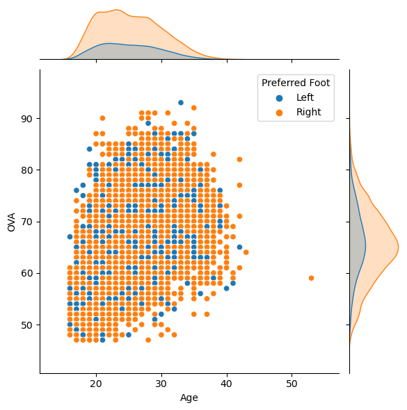

```python
sns.jointplot(data=df,x="Age",y="OVA",hue="Preferred Foot")
```

```python
df.loc[df['Age']>=50,["Name","Nationality"]]
```

|  | Name | Nationality |
| --- | --- | --- |
| 16109 | Kazuyoshi Miura | Japan |

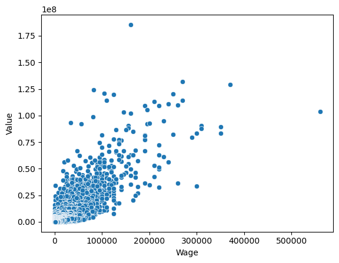

```python
sns.scatterplot(data=df,x="Wage",y="Value")
```

```python
df.loc[df['Value']>=175000000]
```

|  | ID | Name | Nationality | Age | OVA | POT | Club | Contract | Positions | Height | Weight | Preferred Foot | BOV | Best Position | Joined | Value | Wage | Release Clause | Attacking | Crossing | Finishing | Heading Accuracy | Short Passing | Volleys | Skill | Dribbling | Curve | FK Accuracy | Long Passing | … |
| --- | --- | --- | --- | --- | --- | --- | --- | --- | --- | --- | --- | --- | --- | --- | --- | --- | --- | --- | --- | --- | --- | --- | --- | --- | --- | --- | --- | --- | --- | --- |
| 8 | 231747 | Kylian Mbappé | France | 21 | 90 | 95 | Paris Saint-Germain | 2018 - 2022 | ST, LW, RW | 178 | 73.0 | Right | 91 | ST | Jul-01-2018 | 185500000 | 160000 | 203100000 | 408 | 78 | 91 | 73 | 83 | 83 | 394 | 92 | 79 | 63 | 70 | … |

```python
df.loc[df['Wage']>=500000]
```

|  | ID | Name | Nationality | Age | OVA | POT | Club | Contract | Positions | Height | Weight | Preferred Foot | BOV | Best Position | Joined | Value | Wage | Release Clause | Attacking | Crossing | Finishing | Heading Accuracy | Short Passing | Volleys | Skill | Dribbling | Curve | FK Accuracy | Long Passing | … |
| --- | --- | --- | --- | --- | --- | --- | --- | --- | --- | --- | --- | --- | --- | --- | --- | --- | --- | --- | --- | --- | --- | --- | --- | --- | --- | --- | --- | --- | --- | --- |
| 0 | 158023 | Lionel Messi | Argentina | 33 | 93 | 93 | FC Barcelona | 2004 - 2021 | RW, ST, CF | 170 | 72.0 | Left | 93 | RW | Jul-01-2004 | 103500000 | 560000 | 138400000 | 429 | 85 | 95 | 70 | 91 | 88 | 470 | 96 | 93 | 94 | 91 | … |

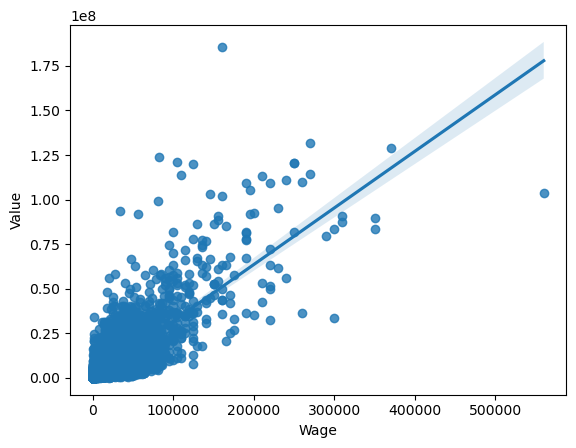

```python
sns.regplot(data=df,x="Wage",y="Value")

plt.show()
```